# Project_Writeup

Tariq Alhindi

Sunday, May 24, 2015

Loading required libararies

```r
library(caret)
library(randomForest)
```

### Preprocessing

Reading datasets and removing columns that have all missing values

```r
rawTrain <- read.csv("pml-training.csv")
training <- read.csv("pml-training-cleaned.csv")
#training <- Filter(function(x){!all(is.na(x))}, rawTrain)

rawTest <- read.csv("pml-testing.csv")
testing <- Filter(function(x){!all(is.na(x))}, rawTest)
```

Removing the first seven columns as they have irrelavant information to the model e.g. username, timestamp…

```r
training <- training[,-c(1:7)]
testing <- testing[,-c(1:7)]
```

### Data Split and Cross Validation

Spliting the training data into new Training and new Testing sets, where the new Training set will consisting of 75% of the original training data, which will be used to build the model. The remaining 25% will be used to test the accuracy of the model before applying it to the 20 test cases that we want to predict.

```r
inTrain     <- createDataPartition(y=training$classe, p=0.75, list=FALSE)
newTraining <- training[inTrain, ]
newTesting  <- training[-inTrain, ]
```

### Exploratory Plots

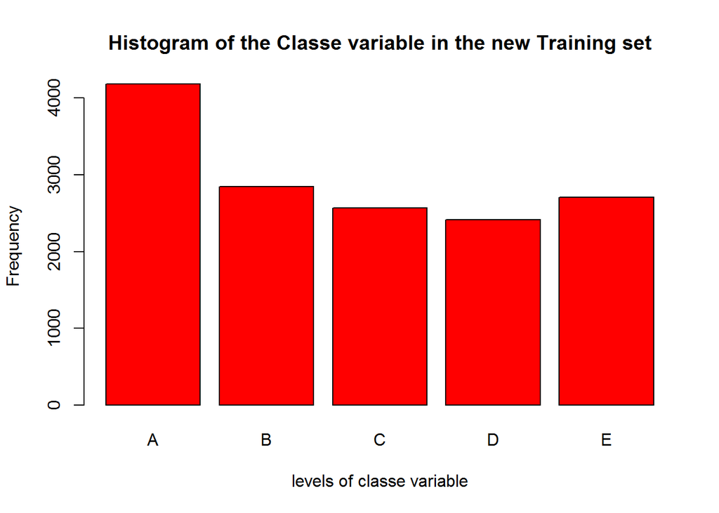

```r
plot(newTraining$classe, col="red", main="Histogram of the Classe variable in the new Training set", xlab="levels of classe variable", ylab="Frequency")
```

### Building the Model and validation:

We use the random forest approach to build the model that consist of 53 predictors. Random forrest was chosen because it had an accuracy > 99% and was eventually able to predict all 20 test cases succesfully upon submission.

```r
modfit <- randomForest(classe ~. , data=newTraining, method="class")
predictions <- predict(modfit, newTesting, type = "class")
```

### Sample Error

As can be seen below, the error is lower than 1% which gives high credibility for our model

```r
confusionMatrix(predictions, newTesting$classe)
```

```
## Confusion Matrix and Statistics
##
##           Reference
## Prediction    A    B    C    D    E
##          A 1394    3    0    0    0
##          B    0  946    2    0    0
##          C    0    0  851    6    1
##          D    0    0    2  797    2
##          E    1    0    0    1  898
##
## Overall Statistics
##
##                Accuracy : 0.9963
##                  95% CI : (0.9942, 0.9978)
##     No Information Rate : 0.2845
##     P-Value [Acc > NIR] : < 2.2e-16
##
##                   Kappa : 0.9954
##  Mcnemar's Test P-Value : NA
##
## Statistics by Class:
##
##                      Class: A Class: B Class: C Class: D Class: E
## Sensitivity            0.9993   0.9968   0.9953   0.9913   0.9967
## Specificity            0.9991   0.9995   0.9983   0.9990   0.9995
## Pos Pred Value         0.9979   0.9979   0.9918   0.9950   0.9978
## Neg Pred Value         0.9997   0.9992   0.9990   0.9983   0.9993
## Prevalence             0.2845   0.1935   0.1743   0.1639   0.1837
## Detection Rate         0.2843   0.1929   0.1735   0.1625   0.1831
## Detection Prevalence   0.2849   0.1933   0.1750   0.1633   0.1835
## Balanced Accuracy      0.9992   0.9982   0.9968   0.9952   0.9981
```

Applying the model to the 20 test cases that we want to predict

```r
TestingDatasetPrediction <- predict(modfit, testing, type = "class")
```

Below are the classes for the 20 test cases of desire

```r
as.character(TestingDatasetPrediction)
```

```
##  [1] "B" "A" "B" "A" "A" "E" "D" "B" "A" "A" "B" "C" "B" "A" "E" "E" "A"
## [18] "B" "B" "B"
```

### Submission

In the end, we use the following function provided in the class to generate the 20 files needed to submit the programming part of the assignment

```r
answers = as.character(TestingDatasetPrediction)

pml_write_files = function(x){
     n = length(x)
     for(i in 1:n){
          filename = paste0("problem_id_",i,".txt")
          write.table(x[i],file=filename,quote=FALSE,row.names=FALSE,col.names=FALSE)
     }
}

pml_write_files(answers)
```